# VISIONS'18: Tucker trawl 2018-07-23

### Cruise number: RR1812 (R/V Roger Revelle)

This notebook shows an estimation of where the time-depth trajectory of the Tucker trawl tow on 2018-07-23 was with respect to the animals in the water column (observed through ADCP).

## Loading ADCP raw beam data

First let's load in some libraries we will need to read and plot the data.

```python
import os, re, glob
import numpy as np
import matplotlib.pyplot as plt
import datetime
import arlpy   # ARL underwater acoustics toolbox
from mpl_toolkits.axes_grid1 import make_axes_locatable

# sys.path.append('/Users/wujung/adcpcode/programs')
from pycurrents.adcp.rdiraw import Multiread
import adcp_func
```

Find out what are the available ADCP raw files.

```python
# Set up paths and params
pname_150 = '/Volumes/current_cruise/adcp/RR1812/raw/os150/'
fname_150 = glob.glob(pname_150+'rr2018_203*.raw')
fname_150.sort()   # sort filename
fname_150
```

```
['/Volumes/current_cruise/adcp/RR1812/raw/os150/rr2018_203_00000.raw',
 '/Volumes/current_cruise/adcp/RR1812/raw/os150/rr2018_203_07200.raw',
 '/Volumes/current_cruise/adcp/RR1812/raw/os150/rr2018_203_14400.raw',
 '/Volumes/current_cruise/adcp/RR1812/raw/os150/rr2018_203_21600.raw',
 '/Volumes/current_cruise/adcp/RR1812/raw/os150/rr2018_203_28800.raw',
 '/Volumes/current_cruise/adcp/RR1812/raw/os150/rr2018_203_36000.raw',
 '/Volumes/current_cruise/adcp/RR1812/raw/os150/rr2018_203_43200.raw',
 '/Volumes/current_cruise/adcp/RR1812/raw/os150/rr2018_203_50400.raw',
 '/Volumes/current_cruise/adcp/RR1812/raw/os150/rr2018_203_57600.raw',
 '/Volumes/current_cruise/adcp/RR1812/raw/os150/rr2018_203_64800.raw',
 '/Volumes/current_cruise/adcp/RR1812/raw/os150/rr2018_203_72000.raw',
 '/Volumes/current_cruise/adcp/RR1812/raw/os150/rr2018_203_79200.raw']
```

It's a bit of a guess work to figure out which files contain the section during the net tow.

Let's give it a try!

```python
m_150,data_150,param_150 = adcp_func.load_raw_files([pname_150+'rr2018_203_72000.raw',pname_150+'rr2018_203_79200.raw'])
```

```
Loading files... (os150.0)
  rr2018_203_72000.raw
  rr2018_203_79200.raw
```

Next we grab the time stamp from the ADCP raw data stream.

```python
# set up x-axis (time stamp) for ADCP data
ping_jump_150 = int(np.floor(data_150.dday.shape[0]/8))
ping_num_150 = np.arange(0,data_150.amp1.shape[0],ping_jump_150)
time_str_150 = [str('%02d'%data_150.rVL['Hour'][x])+':'+str('%02d'%data_150.rVL['Minute'][x]) for x in ping_num_150]
```

Let's plot and check if the data make sense.

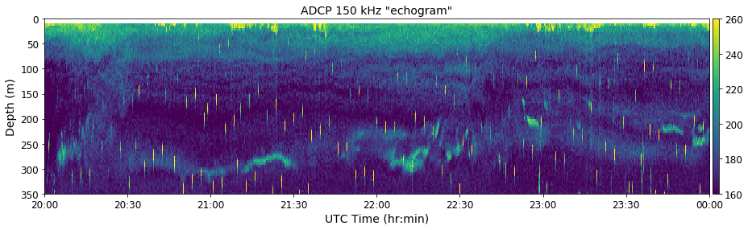

```python
val_mtx = data_150.amp1-param_150['absorption']-2*param_150['spreading_loss']
actual_depth_bin = np.round(param_150['range'],2)

fig = plt.figure(figsize=(15,4))
ax = fig.add_subplot(1,1,1)
im = ax.imshow(val_mtx.T,aspect='auto',interpolation='none',\
               extent=[0,val_mtx.shape[0],actual_depth_bin[-1],actual_depth_bin[0]],\
               vmin=160, vmax=260)
divider = make_axes_locatable(ax)
cax = divider.append_axes("right", size="1%", pad=0.05)
cbar = plt.colorbar(im,cax=cax)
cbar.ax.tick_params(labelsize=12)
ax.set_xticks(ping_num_150)
ax.set_xticklabels(time_str_150,fontsize=12)
ax.set_xlabel('UTC Time (hr:min)',fontsize=14)
ax.set_yticklabels(np.arange(0,400,50),fontsize=12)
ax.set_ylabel('Depth (m)',fontsize=14)
ax.set_ylim([350,0])
ax.set_title('ADCP 150 kHz "echogram"',fontsize=14)
plt.show()
```

## Loading net time-depth trajectory

Let's now try putting the net tow time-depth trajectory onto the echogram to see which were the layers we actually sampled.

```python
import pandas as pd
from pytz import common_timezones
```

```python
csv_pname = '/Volumes/Transcend/Dropbox/Z_wjlee/20180719_ooi_cruise/net_tow/'
csv_fname = '20180723_EAO600m_tow.csv'
```

```python
net = pd.read_csv(csv_pname+csv_fname,\
                 names=['year','month','day','hour','minute',\
                        'angle','pay','messenger'],header=0)
```

```python
net['depth'] = net['pay']*np.sin(net['angle']/180*np.pi)
net['behind_ship'] = net['pay']*np.cos(net['angle']/180*np.pi)
ship_speed = 0.5144*1.5    # Assuming boat speed was 1.5 knots
net['time_offset_sec'] = net['behind_ship']/ship_speed
net
```

|  | year | month | day | hour | minute | angle | pay | messenger | depth | behind_ship | time_offset_sec |
| --- | --- | --- | --- | --- | --- | --- | --- | --- | --- | --- | --- |
| 0 | 2018 | 7 | 23 | 14 | 44 | 38.1 | 4.7 | 0 | 2.900069 | 3.698595 | 4.793409 |
| 1 | 2018 | 7 | 23 | 14 | 49 | 51.2 | 74.3 | 0 | 57.904811 | 46.556663 | 60.337822 |
| 2 | 2018 | 7 | 23 | 14 | 52 | 66.4 | 129.9 | 1 | 119.035519 | 52.005339 | 67.399351 |
| 3 | 2018 | 7 | 23 | 14 | 54 | 66.4 | 129.9 | 0 | 119.035519 | 52.005339 | 67.399351 |
| 4 | 2018 | 7 | 23 | 14 | 59 | 61.0 | 217.2 | 0 | 189.967400 | 105.300650 | 136.470515 |
| 5 | 2018 | 7 | 23 | 15 | 0 | 67.6 | 235.0 | 1 | 217.268318 | 89.551538 | 116.059537 |
| 6 | 2018 | 7 | 23 | 15 | 5 | 65.2 | 209.2 | 0 | 189.907049 | 87.749376 | 113.723919 |
| 7 | 2018 | 7 | 23 | 15 | 10 | 44.1 | 159.5 | 0 | 110.998091 | 114.541144 | 148.446273 |
| 8 | 2018 | 7 | 23 | 15 | 15 | 45.0 | 108.6 | 0 | 76.791796 | 76.791796 | 99.522805 |
| 9 | 2018 | 7 | 23 | 15 | 20 | 54.5 | 64.7 | 0 | 52.673274 | 37.571481 | 48.692951 |
| 10 | 2018 | 7 | 23 | 15 | 25 | 39.5 | 19.7 | 0 | 12.530741 | 15.201004 | 19.700628 |
| 11 | 2018 | 7 | 23 | 15 | 27 | 0.0 | 0.0 | 0 | 0.000000 | 0.000000 | 0.000000 |

## Plotting net time-depth trajectory on ADCP echogram

Now we mess around with the timestamps from the ADCP and the net. The goal is to plot the time-depth trajectory directly on the ADCP echogram.

First we create the timestamp for the time points that were recorded during the tow. This is because I forgot (!) to put the time-depth recorder onto the net like in the first dive on 2018-07-21...! /_\

```python
net_timestamp = pd.to_datetime(net.loc[:, 'year':'minute'])-pd.to_timedelta(net['time_offset_sec'],unit='s')
net_timestamp = net_timestamp.dt.tz_localize('US/Pacific').dt.tz_convert('UTC')  # convert from Pacific to UTC
net_timestamp
```

```
0       2018-07-23 21:43:55.206591+00:00
1       2018-07-23 21:47:59.662178+00:00
2       2018-07-23 21:50:52.600649+00:00
3       2018-07-23 21:52:52.600649+00:00
4       2018-07-23 21:56:43.529485+00:00
5       2018-07-23 21:58:03.940463+00:00
6       2018-07-23 22:03:06.276081+00:00
7       2018-07-23 22:07:31.553727+00:00
8    2018-07-23 22:13:20.477195001+00:00
9       2018-07-23 22:19:11.307049+00:00
10      2018-07-23 22:24:40.299372+00:00
11             2018-07-23 22:27:00+00:00
dtype: datetime64[ns, UTC]
```

```python
net = pd.Series(net.depth.values,index=net_timestamp.values)
```

And then we create the timestamps for the ADCP data.

```python
adcp_timestack = np.vstack((data_150.rVL['Year']+2000,data_150.rVL['Month'],data_150.rVL['Day'],\
                             data_150.rVL['Hour'],data_150.rVL['Minute'],data_150.rVL['Second'])).T
```

```python
adcp_timestamp = pd.to_datetime(pd.DataFrame(adcp_timestack,columns=['year','month','day','hour','minute','second']))
adcp_timestamp = adcp_timestamp.dt.tz_localize('UTC')
```

Now we want to interpolate the net time-depth trajectory onto the same time indices as the ADCP data.

```python
x = pd.concat([net, pd.Series(index=adcp_timestamp)])
net_depth_on_adcp_timestamp = x.groupby(x.index).first().sort_index().interpolate(method='values')[adcp_timestamp]
```

And then we are ready to plot them together!

```python
val_mtx = data_150.amp1-param_150['absorption']-2*param_150['spreading_loss']
actual_depth_bin = np.round(param_150['range'],2)
val_mtx.shape
```

```
(6129, 80)
```

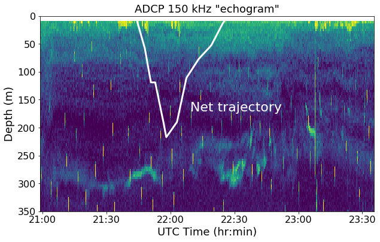

```python
# Plotting
# ADCP echogram
fig = plt.figure(figsize=(10,6))
ax = fig.add_subplot(1,1,1)
im = ax.imshow(val_mtx.T,aspect='auto',interpolation='none',\
               extent=[1000,val_mtx.shape[0],actual_depth_bin[-1],actual_depth_bin[0]],\
               vmin=160, vmax=260)
# divider = make_axes_locatable(ax)
# cax = divider.append_axes("right", size="1%", pad=0.05)
# cbar = plt.colorbar(im,cax=cax)
# cbar.ax.tick_params(labelsize=14)

ax.set_xticks(ping_num_150)
ax.set_xticklabels(time_str_150,fontsize=16)
ax.set_xlabel('UTC Time (hr:min)',fontsize=18)
ax.set_yticklabels(np.arange(0,400,50),fontsize=16)
ax.set_ylabel('Depth (m)',fontsize=18)
ax.set_xlim([1500,5500])
ax.set_ylim([350,0])
ax.set_title('ADCP 150 kHz "echogram"',fontsize=18)

# Net tow trajectory
ax.plot(net_depth_on_adcp_timestamp.values,color='w',linewidth=3)

# Annotation
ax.text(x=3300,y=170,s='Net trajectory',color='w',fontsize=22)

plt.savefig('/Volumes/Transcend/Dropbox/Z_wjlee/20180719_ooi_cruise/net_tow/2018-07-23-adcp-tow.png',dpi=150)
plt.show()
```